# Assignment3

# Problem 1: Predicting Income using Logistic Regression and Decision Trees

## Data Exploration

### Summary

```r
# Since each value is separated by both a comma and a space, we must first remove all spaces from the string
data <- readLines('adult.data')
data <- gsub(" ", "", data)
data <- textConnection(data)
# Now we can prepare the data as a csv, and the na.strings will simply be "?" without the space
data <- read.csv(data, na.strings="?", header=FALSE)
names <- c("age", "workclass", "fnlwgt", "education", "educationNum", "maritalStatus", "occupation", "relationship", "race", "sex", "capitalGain", "capitalLoss", "hoursPerWeek", "nativeCountry", "wage")
colnames(data) <- names

str(data)
```

```
## 'data.frame':    32561 obs. of  15 variables:
##  $ age          : int  39 50 38 53 28 37 49 52 31 42 ...
##  $ workclass    : chr  "State-gov" "Self-emp-not-inc" "Private" "Private" ...
##  $ fnlwgt       : int  77516 83311 215646 234721 338409 284582 160187 209642 45781 159449 ...
##  $ education    : chr  "Bachelors" "Bachelors" "HS-grad" "11th" ...
##  $ educationNum : int  13 13 9 7 13 14 5 9 14 13 ...
##  $ maritalStatus: chr  "Never-married" "Married-civ-spouse" "Divorced" "Married-civ-spouse" ...
##  $ occupation   : chr  "Adm-clerical" "Exec-managerial" "Handlers-cleaners" "Handlers-cleaners" ...
##  $ relationship : chr  "Not-in-family" "Husband" "Not-in-family" "Husband" ...
##  $ race         : chr  "White" "White" "White" "Black" ...
##  $ sex          : chr  "Male" "Male" "Male" "Male" ...
##  $ capitalGain  : int  2174 0 0 0 0 0 0 0 14084 5178 ...
##  $ capitalLoss  : int  0 0 0 0 0 0 0 0 0 0 ...
##  $ hoursPerWeek : int  40 13 40 40 40 40 16 45 50 40 ...
##  $ nativeCountry: chr  "United-States" "United-States" "United-States" "United-States" ...
##  $ wage         : chr  "<=50K" "<=50K" "<=50K" "<=50K" ...
```

```r
summary(data)
```

```
##       age         workclass             fnlwgt         education
##  Min.   :17.00   Length:32561       Min.   :  12285   Length:32561
##  1st Qu.:28.00   Class :character   1st Qu.: 117827   Class :character
##  Median :37.00   Mode  :character   Median : 178356   Mode  :character
##  Mean   :38.58                      Mean   : 189778
##  3rd Qu.:48.00                      3rd Qu.: 237051
##  Max.   :90.00                      Max.   :1484705
##   educationNum   maritalStatus       occupation        relationship
##  Min.   : 1.00   Length:32561       Length:32561       Length:32561
##  1st Qu.: 9.00   Class :character   Class :character   Class :character
##  Median :10.00   Mode  :character   Mode  :character   Mode  :character
##  Mean   :10.08
##  3rd Qu.:12.00
##  Max.   :16.00
##      race               sex             capitalGain     capitalLoss
##  Length:32561       Length:32561       Min.   :    0   Min.   :   0.0
##  Class :character   Class :character   1st Qu.:    0   1st Qu.:   0.0
##  Mode  :character   Mode  :character   Median :    0   Median :   0.0
##                                        Mean   : 1078   Mean   :  87.3
##                                        3rd Qu.:    0   3rd Qu.:   0.0
##                                        Max.   :99999   Max.   :4356.0
##   hoursPerWeek   nativeCountry          wage
##  Min.   : 1.00   Length:32561       Length:32561
##  1st Qu.:40.00   Class :character   Class :character
##  Median :40.00   Mode  :character   Mode  :character
##  Mean   :40.44
##  3rd Qu.:45.00
##  Max.   :99.00
```

### Variable types

- `age`: continuous
- `workclass`: nominal categorical
- `fnlwgt`: continuous
- `education`: ordinal discrete
- `education-num`: ordinal discrete
- `marital-status`: nominal categorical
- `occupation`: nominal categorical
- `relationship`: nominal categorical
- `race`: nominal categorical
- `sex`: nominal categorical
- `capital-gain`: continuous
- `capital-loss`: continuous
- `hours-per-week`: continuous
- `native-country`: nominal categorical
- `wage`: ordinal categorical

** Even though the dataset lists `education-num` as being continuous, it represents the numerical values associated with the ordinal variable `education`, thereby making it discrete.**

## Data Manipulation

### Replace missing data

```r
# create function to determine mode
getMode <- function(c) {
  # only consider non-null values
  uniqueC <- unique(c[!is.na(c)])
  # return value that appears most
  uniqueC[which.max(tabulate(match(c, uniqueC)))]
}
```

#### Split Data for Training and Testing

```r
library(caret)
set.seed(2)
indices <- createDataPartition(data$wage, p=.8, list=FALSE)
training_data <- data[indices,]
testing_data <- data[-indices,]
```

#### Replace Missing Values with Mode of Training Data

```r
# Print the names of the columns that contain missing data
names(which(colSums(is.na(data)) > 0))
```

```
## [1] "workclass"     "occupation"    "nativeCountry"
```

```r
# replace NA categorical vals with the mode of the data

# Get Modes
workclass_mode <- getMode(training_data$workclass)
occupation_mode <- getMode(training_data$occupation)
country_mode <- getMode(training_data$nativeCountry)

# Training Data
training_data$workclass[which(is.na(training_data$workclass))] <- workclass_mode
training_data$occupation[which(is.na(training_data$occupation))] <- occupation_mode
training_data$nativeCountry[which(is.na(training_data$nativeCountry))] <- country_mode

# Testing Data
testing_data$workclass[which(is.na(testing_data$workclass))] <- workclass_mode
testing_data$occupation[which(is.na(testing_data$occupation))] <- occupation_mode
testing_data$nativeCountry[which(is.na(testing_data$nativeCountry))] <- country_mode
```

### Convert Ordinal Variables to Numeric

```r
# education-num already represents numeric ordinal for education

# Convert wage from strings to numbers
ordinal_wage <- data[,"wage"]
ordinal_wage[which(ordinal_wage == "<=50K")] <- 0
ordinal_wage[which(ordinal_wage == ">50K")] <- 1
```

### Run Statistical Tests on Variables

```r
# setup
library(gmodels)
library(vcd)
```

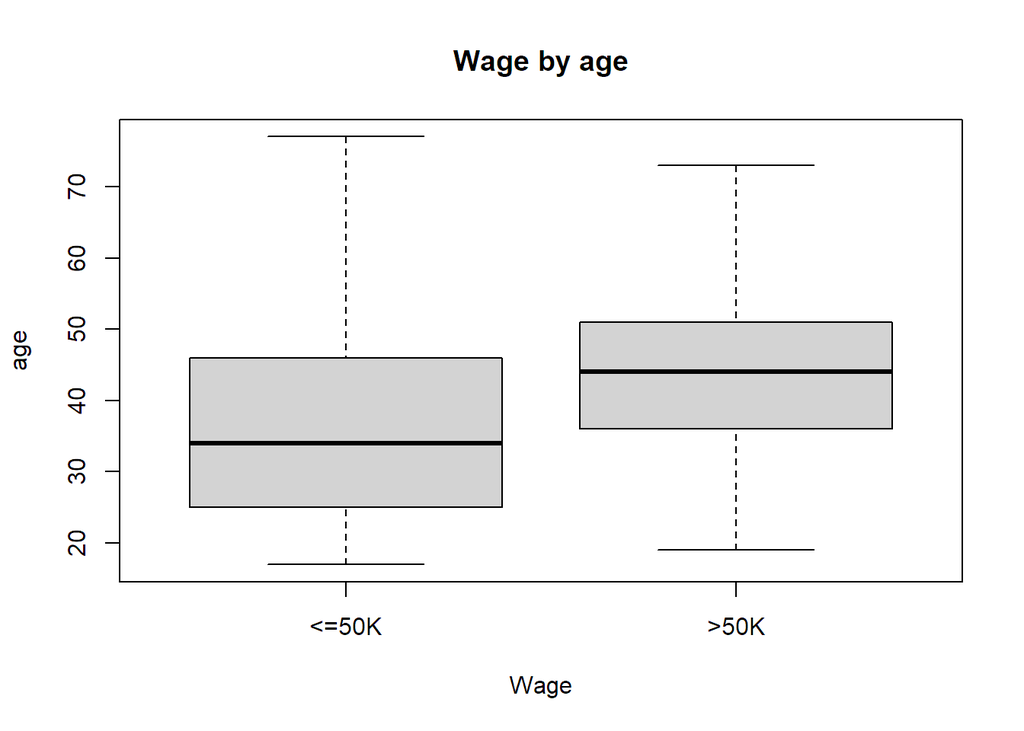

```
##
##  Welch Two Sample t-test
##
## data:  otherC by wage
## t = -50.264, df = 17411, p-value < 2.2e-16
## alternative hypothesis: true difference in means between group <=50K and group >50K is not equal to 0
## 95 percent confidence interval:
##  -7.757250 -7.174955
## sample estimates:
## mean in group <=50K  mean in group >50K
##            36.78374            44.24984
```

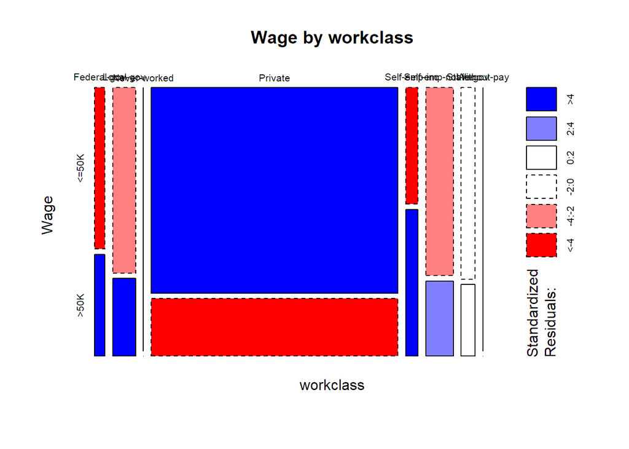

```
##
##
##    Cell Contents
## |-------------------------|
## |                       N |
## | Chi-square contribution |
## |           N / Row Total |
## |           N / Col Total |
## |         N / Table Total |
## |-------------------------|
##
##
## Total Observations in Table:  30725
##
##
##                  | wage
##           otherC |     <=50K |      >50K | Row Total |
## -----------------|-----------|-----------|-----------|
##      Federal-gov |       589 |       371 |       960 |
##                  |    24.159 |    72.871 |           |
##                  |     0.614 |     0.386 |     0.031 |
##                  |     0.026 |     0.048 |           |
##                  |     0.019 |     0.012 |           |
## -----------------|-----------|-----------|-----------|
##        Local-gov |      1476 |       617 |      2093 |
##                  |     5.848 |    17.640 |           |
##                  |     0.705 |     0.295 |     0.068 |
##                  |     0.064 |     0.081 |           |
##                  |     0.048 |     0.020 |           |
## -----------------|-----------|-----------|-----------|
##     Never-worked |         7 |         0 |         7 |
##                  |     0.578 |     1.743 |           |
##                  |     1.000 |     0.000 |     0.000 |
##                  |     0.000 |     0.000 |           |
##                  |     0.000 |     0.000 |           |
## -----------------|-----------|-----------|-----------|
##          Private |     17733 |      4963 |     22696 |
##                  |    27.763 |    83.744 |           |
##                  |     0.781 |     0.219 |     0.739 |
##                  |     0.768 |     0.649 |           |
```

[output cut: 25 more lines]

```
## -----------------|-----------|-----------|-----------|
##     Column Total |     23075 |      7650 |     30725 |
##                  |     0.751 |     0.249 |           |
## -----------------|-----------|-----------|-----------|
##
##
## Statistics for All Table Factors
##
##
## Pearson's Chi-squared test
## ------------------------------------------------------------
## Chi^2 =  827.7184     d.f. =  7     p =  1.933848e-174
##
##
##
```

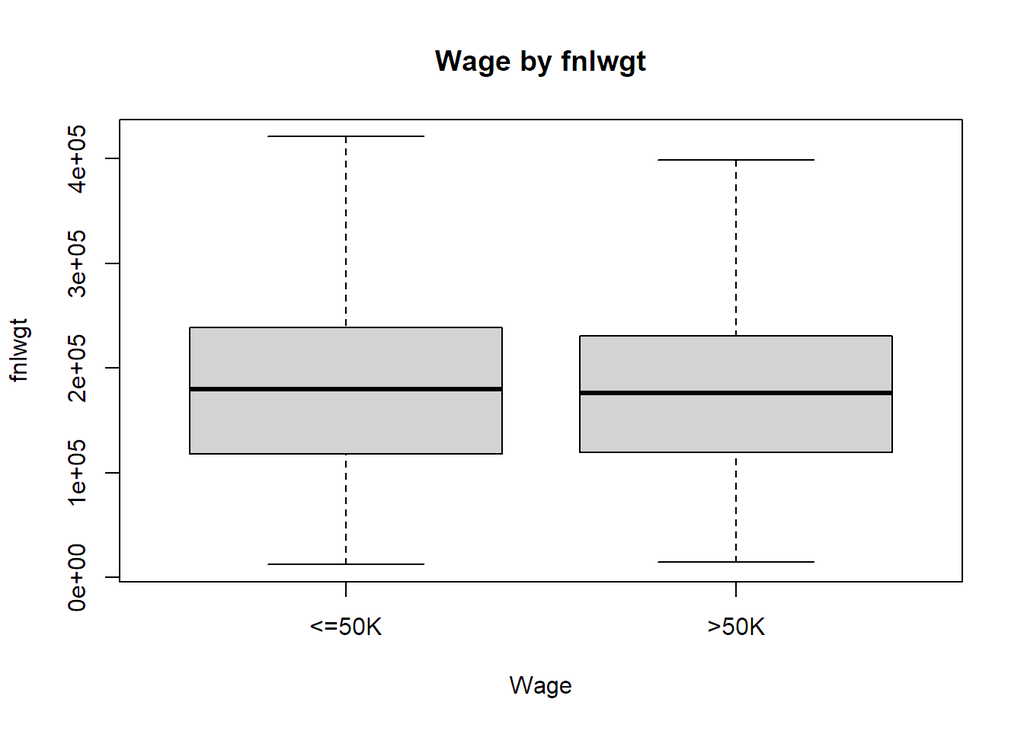

```
##
##  Welch Two Sample t-test
##
## data:  otherC by wage
## t = 1.7412, df = 13615, p-value = 0.08167
## alternative hypothesis: true difference in means between group <=50K and group >50K is not equal to 0
## 95 percent confidence interval:
##  -293.7029 4965.4332
## sample estimates:
## mean in group <=50K  mean in group >50K
##            190340.9            188005.0
##
##
##  One-way analysis of means (not assuming equal variances)
##
## data:  as.numeric(otherC) and wage
## F = 4211.5, num df = 1, denom df = 13421, p-value < 2.2e-16
```

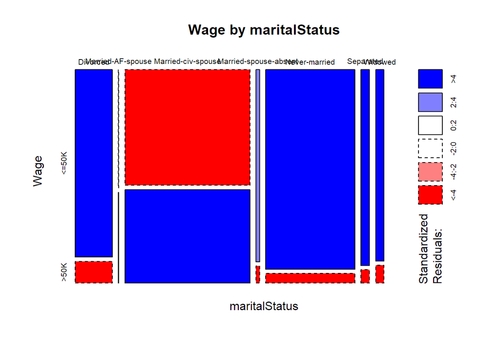

```
##
##
##    Cell Contents
## |-------------------------|
## |                       N |
## | Chi-square contribution |
## |           N / Row Total |
## |           N / Col Total |
## |         N / Table Total |
## |-------------------------|
##
##
## Total Observations in Table:  32561
##
##
##                       | wage
##                otherC |     <=50K |      >50K | Row Total |
## ----------------------|-----------|-----------|-----------|
##              Divorced |      3980 |       463 |      4443 |
##                       |   109.202 |   344.277 |           |
##                       |     0.896 |     0.104 |     0.136 |
##                       |     0.161 |     0.059 |           |
##                       |     0.122 |     0.014 |           |
## ----------------------|-----------|-----------|-----------|
##     Married-AF-spouse |        13 |        10 |        23 |
##                       |     1.140 |     3.594 |           |
##                       |     0.565 |     0.435 |     0.001 |
##                       |     0.001 |     0.001 |           |
##                       |     0.000 |     0.000 |           |
## ----------------------|-----------|-----------|-----------|
##    Married-civ-spouse |      8284 |      6692 |     14976 |
##                       |   837.419 |  2640.097 |           |
##                       |     0.553 |     0.447 |     0.460 |
##                       |     0.335 |     0.853 |           |
##                       |     0.254 |     0.206 |           |
## ----------------------|-----------|-----------|-----------|
## Married-spouse-absent |       384 |        34 |       418 |
##                       |    14.002 |    44.143 |           |
##                       |     0.919 |     0.081 |     0.013 |
##                       |     0.016 |     0.004 |           |
```

[output cut: 19 more lines]

```
## ----------------------|-----------|-----------|-----------|
##          Column Total |     24720 |      7841 |     32561 |
##                       |     0.759 |     0.241 |           |
## ----------------------|-----------|-----------|-----------|
##
##
## Statistics for All Table Factors
##
##
## Pearson's Chi-squared test
## ------------------------------------------------------------
## Chi^2 =  6517.742     d.f. =  6     p =  0
##
##
##
```

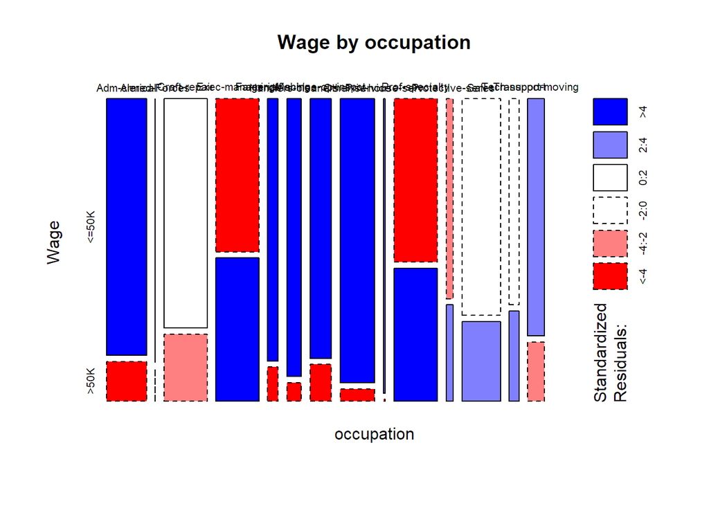

```
##
##
##    Cell Contents
## |-------------------------|
## |                       N |
## | Chi-square contribution |
## |           N / Row Total |
## |           N / Col Total |
## |         N / Table Total |
## |-------------------------|
##
##
## Total Observations in Table:  30718
##
##
##                   | wage
##            otherC |     <=50K |      >50K | Row Total |
## ------------------|-----------|-----------|-----------|
##      Adm-clerical |      3263 |       507 |      3770 |
##                   |    65.882 |   198.662 |           |
##                   |     0.866 |     0.134 |     0.123 |
##                   |     0.141 |     0.066 |           |
##                   |     0.106 |     0.017 |           |
## ------------------|-----------|-----------|-----------|
##      Armed-Forces |         8 |         1 |         9 |
##                   |     0.228 |     0.688 |           |
##                   |     0.889 |     0.111 |     0.000 |
##                   |     0.000 |     0.000 |           |
##                   |     0.000 |     0.000 |           |
## ------------------|-----------|-----------|-----------|
##      Craft-repair |      3170 |       929 |      4099 |
##                   |     2.739 |     8.258 |           |
##                   |     0.773 |     0.227 |     0.133 |
##                   |     0.137 |     0.121 |           |
##                   |     0.103 |     0.030 |           |
## ------------------|-----------|-----------|-----------|
##   Exec-managerial |      2098 |      1968 |      4066 |
##                   |   298.944 |   901.444 |           |
##                   |     0.516 |     0.484 |     0.132 |
##                   |     0.091 |     0.257 |           |
```

[output cut: 61 more lines]

```
## ------------------|-----------|-----------|-----------|
##      Column Total |     23068 |      7650 |     30718 |
##                   |     0.751 |     0.249 |           |
## ------------------|-----------|-----------|-----------|
##
##
## Statistics for All Table Factors
##
##
## Pearson's Chi-squared test
## ------------------------------------------------------------
## Chi^2 =  3744.899     d.f. =  13     p =  0
##
##
##
```

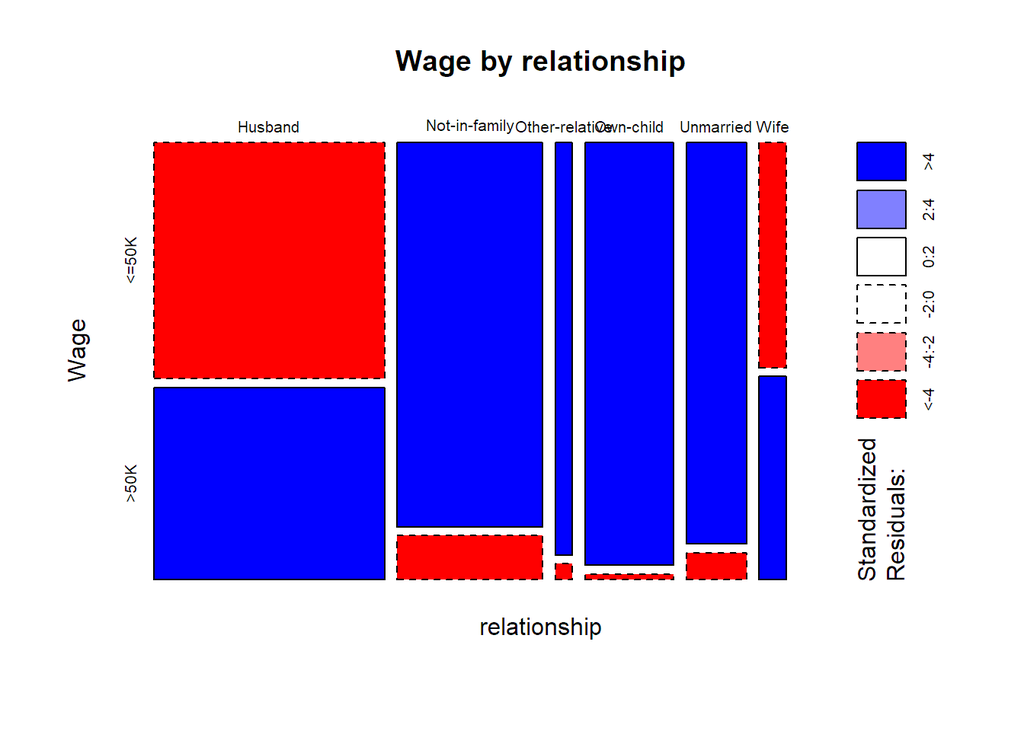

```
##
##
##    Cell Contents
## |-------------------------|
## |                       N |
## | Chi-square contribution |
## |           N / Row Total |
## |           N / Col Total |
## |         N / Table Total |
## |-------------------------|
##
##
## Total Observations in Table:  32561
##
##
##                | wage
##         otherC |     <=50K |      >50K | Row Total |
## ---------------|-----------|-----------|-----------|
##        Husband |      7275 |      5918 |     13193 |
##                |   750.108 |  2364.834 |           |
##                |     0.551 |     0.449 |     0.405 |
##                |     0.294 |     0.755 |           |
##                |     0.223 |     0.182 |           |
## ---------------|-----------|-----------|-----------|
##  Not-in-family |      7449 |       856 |      8305 |
##                |   207.541 |   654.305 |           |
##                |     0.897 |     0.103 |     0.255 |
##                |     0.301 |     0.109 |           |
##                |     0.229 |     0.026 |           |
## ---------------|-----------|-----------|-----------|
## Other-relative |       944 |        37 |       981 |
##                |    53.298 |   168.029 |           |
##                |     0.962 |     0.038 |     0.030 |
##                |     0.038 |     0.005 |           |
##                |     0.029 |     0.001 |           |
## ---------------|-----------|-----------|-----------|
##      Own-child |      5001 |        67 |      5068 |
##                |   345.772 |  1090.101 |           |
##                |     0.987 |     0.013 |     0.156 |
##                |     0.202 |     0.009 |           |
```

[output cut: 13 more lines]

```
## ---------------|-----------|-----------|-----------|
##   Column Total |     24720 |      7841 |     32561 |
##                |     0.759 |     0.241 |           |
## ---------------|-----------|-----------|-----------|
##
##
## Statistics for All Table Factors
##
##
## Pearson's Chi-squared test
## ------------------------------------------------------------
## Chi^2 =  6699.077     d.f. =  5     p =  0
##
##
##
```

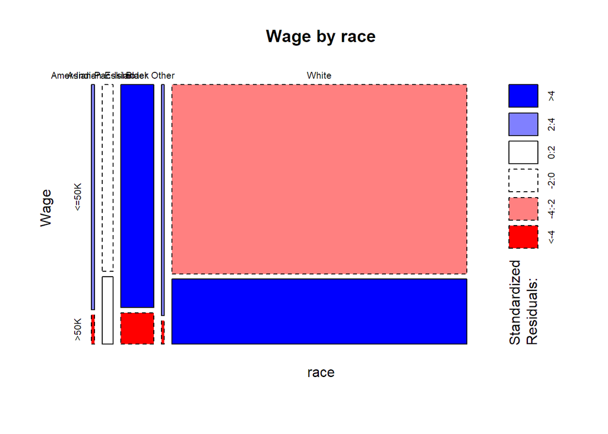

```
##
##
##    Cell Contents
## |-------------------------|
## |                       N |
## | Chi-square contribution |
## |           N / Row Total |
## |           N / Col Total |
## |         N / Table Total |
## |-------------------------|
##
##
## Total Observations in Table:  32561
##
##
##                    | wage
##             otherC |     <=50K |      >50K | Row Total |
## -------------------|-----------|-----------|-----------|
## Amer-Indian-Eskimo |       275 |        36 |       311 |
##                    |     6.406 |    20.197 |           |
##                    |     0.884 |     0.116 |     0.010 |
##                    |     0.011 |     0.005 |           |
##                    |     0.008 |     0.001 |           |
## -------------------|-----------|-----------|-----------|
## Asian-Pac-Islander |       763 |       276 |      1039 |
##                    |     0.844 |     2.660 |           |
##                    |     0.734 |     0.266 |     0.032 |
##                    |     0.031 |     0.035 |           |
##                    |     0.023 |     0.008 |           |
## -------------------|-----------|-----------|-----------|
##              Black |      2737 |       387 |      3124 |
##                    |    56.262 |   177.373 |           |
##                    |     0.876 |     0.124 |     0.096 |
##                    |     0.111 |     0.049 |           |
##                    |     0.084 |     0.012 |           |
## -------------------|-----------|-----------|-----------|
##              Other |       246 |        25 |       271 |
##                    |     7.878 |    24.837 |           |
##                    |     0.908 |     0.092 |     0.008 |
##                    |     0.010 |     0.003 |           |
##                    |     0.008 |     0.001 |           |
## -------------------|-----------|-----------|-----------|
##              White |     20699 |      7117 |     27816 |
##                    |     8.299 |    26.165 |           |
##                    |     0.744 |     0.256 |     0.854 |
##                    |     0.837 |     0.908 |           |
##                    |     0.636 |     0.219 |           |
## -------------------|-----------|-----------|-----------|
##       Column Total |     24720 |      7841 |     32561 |
##                    |     0.759 |     0.241 |           |
## -------------------|-----------|-----------|-----------|
##
##
## Statistics for All Table Factors
##
##
## Pearson's Chi-squared test
## ------------------------------------------------------------
## Chi^2 =  330.9204     d.f. =  4     p =  2.305961e-70
##
##
##
```

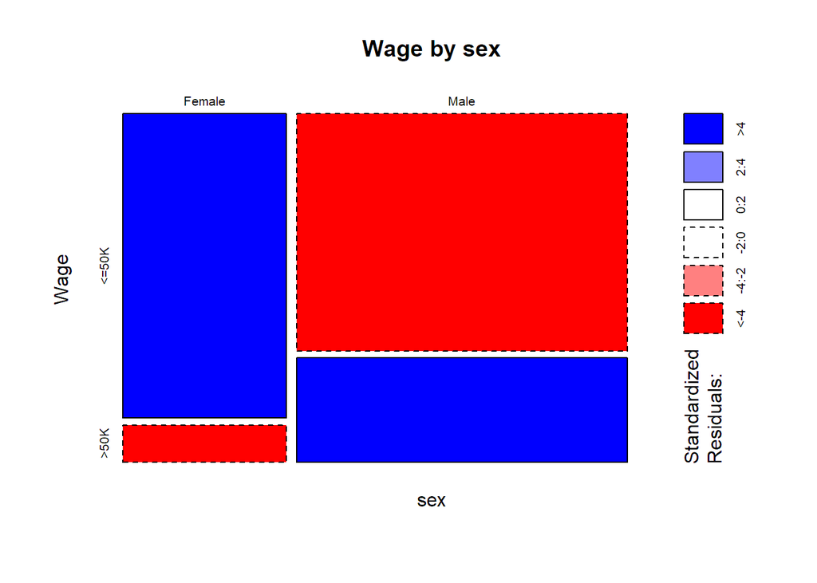

```
##
##
##    Cell Contents
## |-------------------------|
## |                       N |
## | Chi-square contribution |
## |           N / Row Total |
## |           N / Col Total |
## |         N / Table Total |
## |-------------------------|
##
##
## Total Observations in Table:  32561
##
##
##              | wage
##       otherC |     <=50K |      >50K | Row Total |
## -------------|-----------|-----------|-----------|
##       Female |      9592 |      1179 |     10771 |
##              |   244.770 |   771.677 |           |
##              |     0.891 |     0.109 |     0.331 |
##              |     0.388 |     0.150 |           |
##              |     0.295 |     0.036 |           |
## -------------|-----------|-----------|-----------|
##         Male |     15128 |      6662 |     21790 |
##              |   120.992 |   381.447 |           |
##              |     0.694 |     0.306 |     0.669 |
##              |     0.612 |     0.850 |           |
##              |     0.465 |     0.205 |           |
## -------------|-----------|-----------|-----------|
## Column Total |     24720 |      7841 |     32561 |
##              |     0.759 |     0.241 |           |
## -------------|-----------|-----------|-----------|
##
##
## Statistics for All Table Factors
##
##
## Pearson's Chi-squared test
## ------------------------------------------------------------
## Chi^2 =  1518.887     d.f. =  1     p =  0
##
## Pearson's Chi-squared test with Yates' continuity correction
## ------------------------------------------------------------
## Chi^2 =  1517.813     d.f. =  1     p =  0
##
##
```

[figure not shown]

```
##
##  Welch Two Sample t-test
##
## data:  otherC by wage
## t = -23.427, df = 7861.7, p-value < 2.2e-16
## alternative hypothesis: true difference in means between group <=50K and group >50K is not equal to 0
## 95 percent confidence interval:
##  -4180.166 -3534.614
## sample estimates:
## mean in group <=50K  mean in group >50K
##            148.7525           4006.1425
```

[figure not shown]

```
##
##  Welch Two Sample t-test
##
## data:  otherC by wage
## t = -20.238, df = 9231.1, p-value < 2.2e-16
## alternative hypothesis: true difference in means between group <=50K and group >50K is not equal to 0
## 95 percent confidence interval:
##  -155.5985 -128.1187
## sample estimates:
## mean in group <=50K  mean in group >50K
##            53.14292           195.00153
```

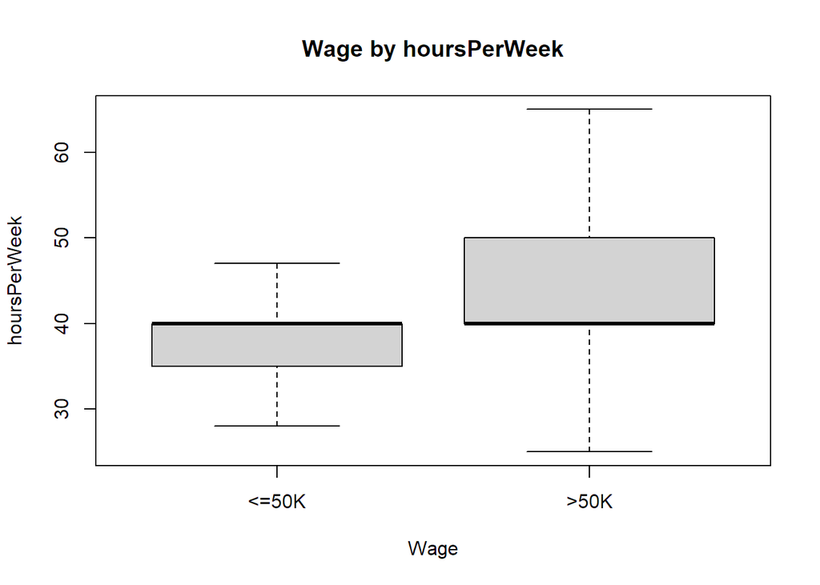

```
##
##  Welch Two Sample t-test
##
## data:  otherC by wage
## t = -45.123, df = 14570, p-value < 2.2e-16
## alternative hypothesis: true difference in means between group <=50K and group >50K is not equal to 0
## 95 percent confidence interval:
##  -6.920943 -6.344690
## sample estimates:
## mean in group <=50K  mean in group >50K
##            38.84021            45.47303
```

```r
# for each column in the bank dataset, determine the classification of the data by referring to the cat vector and run the appropriate test based on that value
c <- 1
wage <- data[,"wage"]
while(c < length(cat)){
  otherC <- data[,c]
  otherN <- colnames(data[c])

  # skip education, as the data represents ordinal values but is not formatted numerically
  if(otherN == "education"){
    c <- c + 1
    next
  }
  if(cat[c] == n){
    # nominal value, use mosaic plot and chi-sq test
    mosaicplot(table(otherC, wage), xlab = otherN, ylab = "Wage", main = paste("Wage by", otherN), shade=T)
    CrossTable(otherC, wage, chisq=T)
  }else if(cat[c] == o){
    # ordinal value, use One-Way ANOVA Test
    anova <- oneway.test(as.numeric(otherC)~wage)
      print(anova)
  }else{
    # continuous value, use Side-By-Side Boxplot
    boxplot(otherC~wage, main = paste("Wage by", otherN), xlab = "Wage", ylab = otherN, outline=F)
    print(t.test(otherC~wage, alternative="two.sided"))
  }
  c <- c + 1
}
```